# Praca domowa 2

Piotr Obarski

Modele liniowe i mieszane

Task: Compare range distribution (or studentized range distribution) for SNK/HSD tests between two scenarios:  
- all groups have equal size (so called balanced case),  
- some groups have unequal size (so called unbalanced case).

You may use KS-test or QQplots to verify if both distributions are equal.

Try different number of groups and different ways in which classes may be unequal.

Results in form of knitr report shall be submitted on GitHub.

## Solution

I will compute range distribution (not studentized) for HSD test. That is the distribution between the highest and lowest means of groups. For SNK it would be different since groups are sorted by means and ranges are computed for each pair separately. (I treat operator “/” in SNK/HSD as “or”, and I will do analysis only for HSD test).

Firstly, I will check the laws of range for 60 observations derived from normal distribution which are grouped in 4 groups, in one case each containg 15 observations, in the other groups have 10, 20, 15, 15 observations.

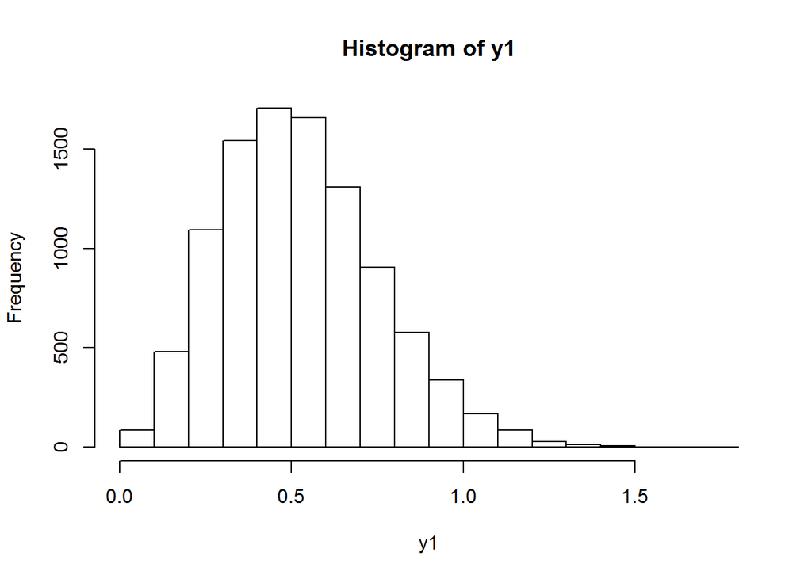

```r
y1=replicate (10000, {a<-rnorm(60)
level<-rep(1:4, times=15)
b<-tapply(a,level,mean)
b[which.max(b)]-b[which.min(b)]
})
hist(y1)
```

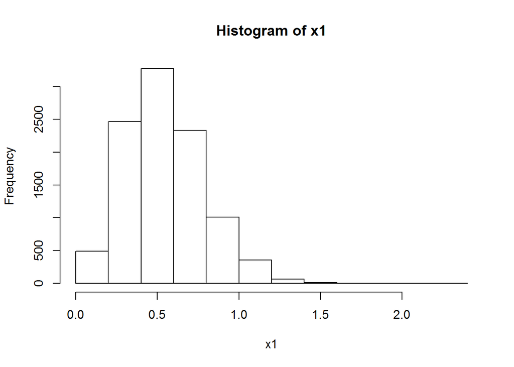

```r
x1=replicate (10000, {a<-rnorm(60)
level<-c(rep(1, times=10),rep(2, times=20),rep(3, times=15), rep(4, times=15))
b<-tapply(a,level,mean)
b[which.max(b)]-b[which.min(b)]
})
hist(x1)
```

```r
ks.test(x1, y1)
```

```
##
##  Two-sample Kolmogorov-Smirnov test
##
## data:  x1 and y1
## D = 0.0352, p-value = 8.317e-06
## alternative hypothesis: two-sided
```

On histograms, we see that distributions can be the same. But they are not and significant difference in distributions of x1 and y1 is indicated by small p-value in Kolmogorov-Smirnov test.

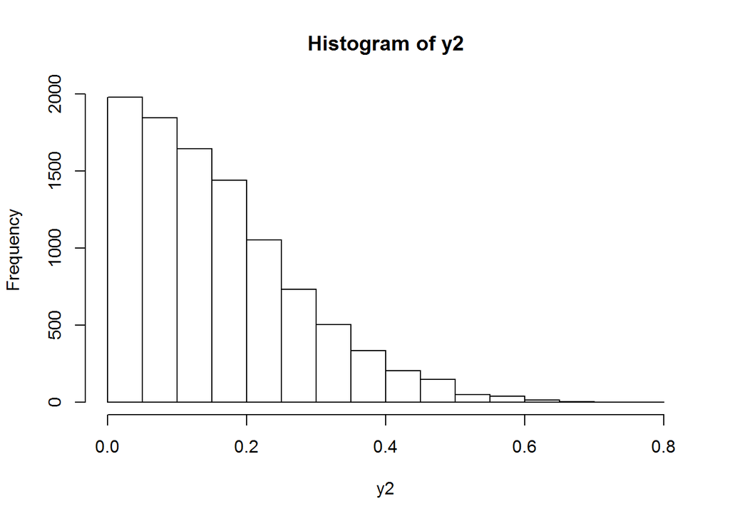

```r
y2=replicate (10000, {a<-rnorm(100)
level<-rep(1:2, times=50)
b<-tapply(a,level,mean)
b[which.max(b)]-b[which.min(b)]
})
hist(y2)
```

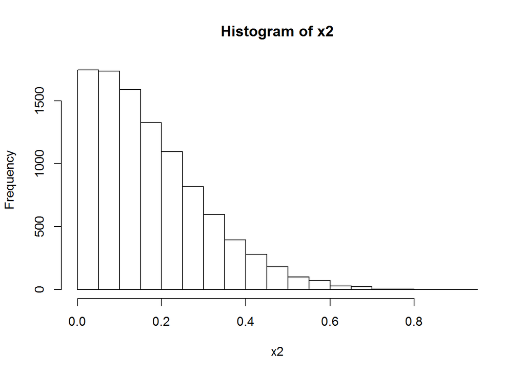

```r
x2=replicate (10000, {a<-rnorm(100)
level<-c(rep(1, times=70),rep(2, times=30))
b<-tapply(a,level,mean)
b[which.max(b)]-b[which.min(b)]
})
hist(x2)
```

```r
ks.test(x2, y2)
```

```
##
##  Two-sample Kolmogorov-Smirnov test
##
## data:  x2 and y2
## D = 0.0525, p-value = 2.142e-12
## alternative hypothesis: two-sided
```

Here we get the same conclusion with small p-value in Kolmogorov-Smirnov test, which indicates different distributions. What is interesting is the distribution of y1 compared with distribution of y2. They have completely different shapes. Let’s check it how it looks for 3 groups.

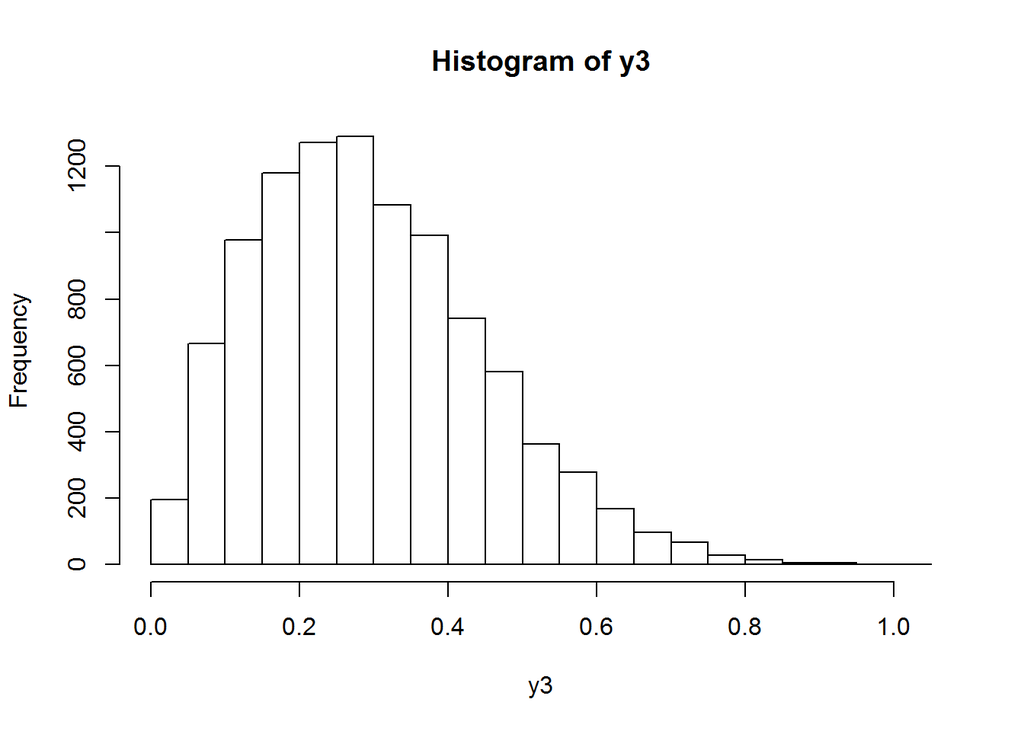

```r
y3=replicate (10000, {a<-rnorm(99)
level<-rep(1:3, times=33)
b<-tapply(a,level,mean)
b[which.max(b)]-b[which.min(b)]
})
hist(y3)
```

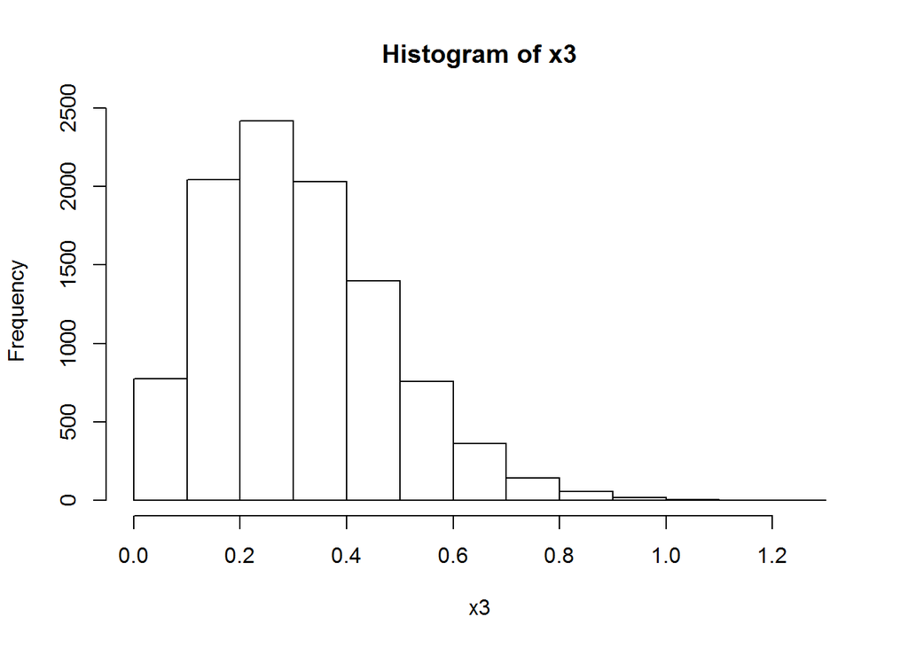

```r
x3=replicate (10000, {a<-rnorm(99)
level<-c(rep(1, times=20),rep(2, times=30),rep(3, times=49))
b<-tapply(a,level,mean)
b[which.max(b)]-b[which.min(b)]
})
hist(x3)
```

```r
ks.test(x3, y3)
```

```
##
##  Two-sample Kolmogorov-Smirnov test
##
## data:  x3 and y3
## D = 0.0406, p-value = 1.388e-07
## alternative hypothesis: two-sided
```

I could just rewrite what I have written after the previous test. What is worth of noting is that distribution of y3 is unlike the distributions of y1 and y2, as we can see on histograms.

I will carry out one more experiment for normal distribution, with two groups, in one case divided evenly, in second divided on subgroups with 55 numbers and 45 (so the difference is not so big).

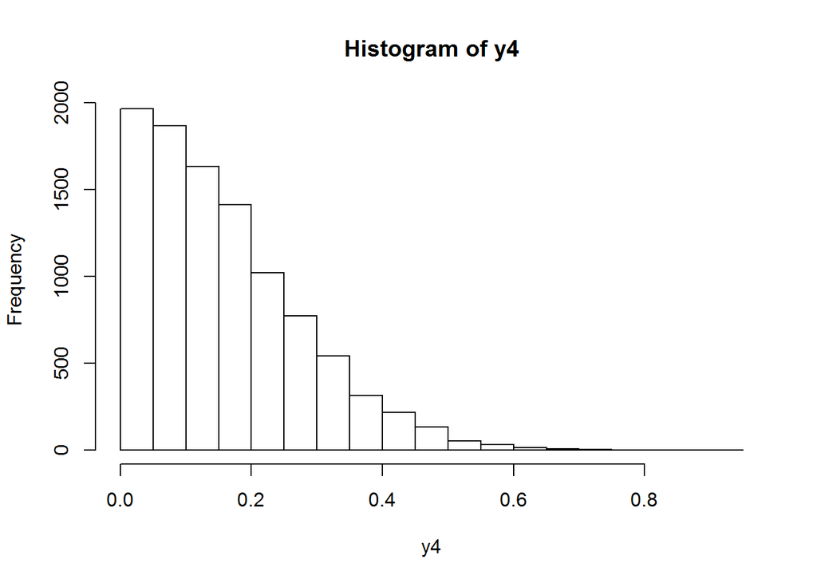

```r
y4=replicate (10000, {a<-rnorm(100)
level<-rep(1:2, times=50)
b<-tapply(a,level,mean)
b[which.max(b)]-b[which.min(b)]
})
hist(y4)
```

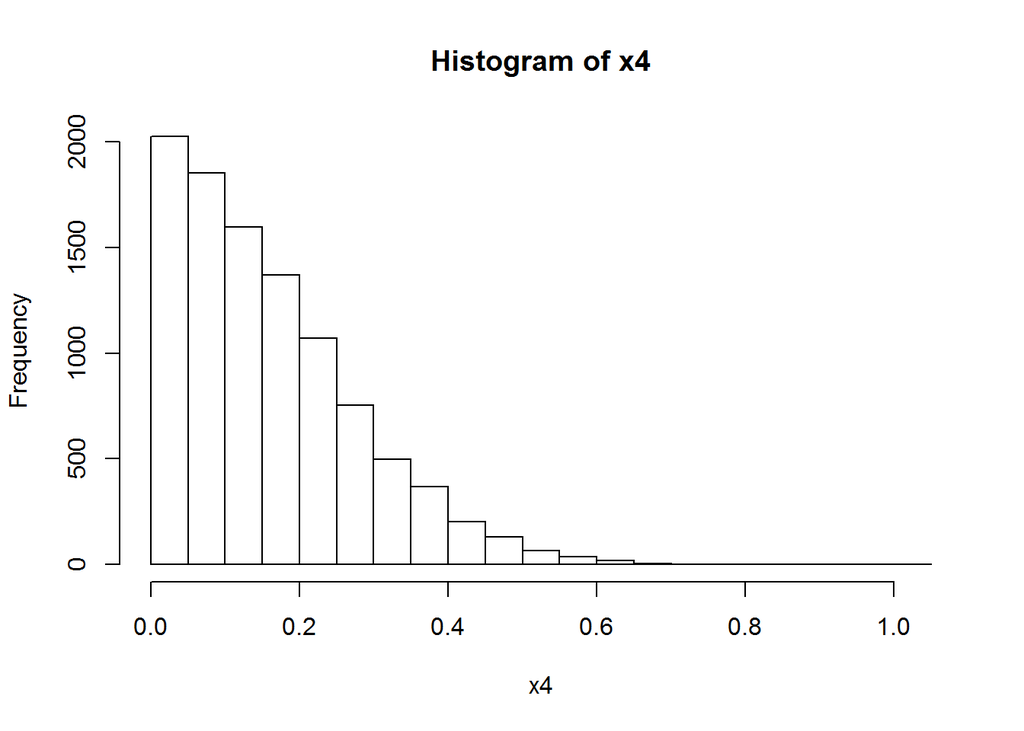

```r
x4=replicate (10000, {a<-rnorm(100)
level<-c(rep(1, times=55),rep(2, times=45))
b<-tapply(a,level,mean)
b[which.max(b)]-b[which.min(b)]
})
hist(x4)
```

```r
ks.test(x4, y4)
```

```
##
##  Two-sample Kolmogorov-Smirnov test
##
## data:  x4 and y4
## D = 0.0095, p-value = 0.7576
## alternative hypothesis: two-sided
```

In this case I got very different p-values. Sometimes it was as high as 0.995 and sometimes as low as 0.0541, but never less then 0.05. So in this case we can assume that distributions are the same.